# Feature importances

from

> https://github.com/UBC-CS/cpsc330

## Data

In the first part of this lecture, we'll be using [Kaggle House Prices dataset](https://www.kaggle.com/c/home-data-for-ml-course/). As usual, to run this notebook you'll need to download the data. Unzip the data into a subdirectory called `data`. For this dataset, train and test have already been separated. We'll be working with the train portion in this lecture.

```python
df = pd.read_csv("data/housing-kaggle/train.csv")
train_df, test_df = train_test_split(df, test_size=0.10, random_state=123)
train_df.head()
```

|  | Id | MSSubClass | MSZoning | LotFrontage | LotArea | Street | Alley | LotShape | LandContour | Utilities | ... | PoolArea | PoolQC | Fence | MiscFeature | MiscVal | MoSold | YrSold | SaleType | SaleCondition | SalePrice |
| --- | --- | --- | --- | --- | --- | --- | --- | --- | --- | --- | --- | --- | --- | --- | --- | --- | --- | --- | --- | --- | --- |
| 302 | 303 | 20 | RL | 118.0 | 13704 | Pave | NaN | IR1 | Lvl | AllPub | ... | 0 | NaN | NaN | NaN | 0 | 1 | 2006 | WD | Normal | 205000 |
| 767 | 768 | 50 | RL | 75.0 | 12508 | Pave | NaN | IR1 | Lvl | AllPub | ... | 0 | NaN | NaN | Shed | 1300 | 7 | 2008 | WD | Normal | 160000 |
| 429 | 430 | 20 | RL | 130.0 | 11457 | Pave | NaN | IR1 | Lvl | AllPub | ... | 0 | NaN | NaN | NaN | 0 | 3 | 2009 | WD | Normal | 175000 |
| 1139 | 1140 | 30 | RL | 98.0 | 8731 | Pave | NaN | IR1 | Lvl | AllPub | ... | 0 | NaN | NaN | NaN | 0 | 5 | 2007 | WD | Normal | 144000 |
| 558 | 559 | 60 | RL | 57.0 | 21872 | Pave | NaN | IR2 | HLS | AllPub | ... | 0 | NaN | NaN | NaN | 0 | 8 | 2008 | WD | Normal | 175000 |

5 rows × 81 columns

- The prediction task is predicting `SalePrice` given features related to properties.
- Note that the target is numeric, not categorical.

```python
train_df.shape
```

```
(1314, 81)
```

### Let's separate `X` and `y`

```python
X_train = train_df.drop(columns=["SalePrice"])
y_train = train_df["SalePrice"]

X_test = test_df.drop(columns=["SalePrice"])
y_test = test_df["SalePrice"]
```

### Let's identify feature types

```python
drop_features = ["Id"]
numeric_features = [
    "BedroomAbvGr",
    "KitchenAbvGr",
    "LotFrontage",
    "LotArea",
    "OverallQual",
    "OverallCond",
    "YearBuilt",
    "YearRemodAdd",
    "MasVnrArea",
    "BsmtFinSF1",
    "BsmtFinSF2",
    "BsmtUnfSF",
    "TotalBsmtSF",
    "1stFlrSF",
    "2ndFlrSF",
    "LowQualFinSF",
    "GrLivArea",
    "BsmtFullBath",
    "BsmtHalfBath",
    "FullBath",
    "HalfBath",
    "TotRmsAbvGrd",
    "Fireplaces",
    "GarageYrBlt",
    "GarageCars",
    "GarageArea",
    "WoodDeckSF",
    "OpenPorchSF",
    "EnclosedPorch",
    "3SsnPorch",
    "ScreenPorch",
    "PoolArea",
    "MiscVal",
    "YrSold",
]
```

```python
ordinal_features_reg = [
    "ExterQual",
    "ExterCond",
    "BsmtQual",
    "BsmtCond",
    "HeatingQC",
    "KitchenQual",
    "FireplaceQu",
    "GarageQual",
    "GarageCond",
    "PoolQC",
]
ordering = [
    "Po",
    "Fa",
    "TA",
    "Gd",
    "Ex",
]  # if N/A it will just impute something, per below
ordering_ordinal_reg = [ordering] * len(ordinal_features_reg)
ordering_ordinal_reg
```

```
[['Po', 'Fa', 'TA', 'Gd', 'Ex'],
 ['Po', 'Fa', 'TA', 'Gd', 'Ex'],
 ['Po', 'Fa', 'TA', 'Gd', 'Ex'],
 ['Po', 'Fa', 'TA', 'Gd', 'Ex'],
 ['Po', 'Fa', 'TA', 'Gd', 'Ex'],
 ['Po', 'Fa', 'TA', 'Gd', 'Ex'],
 ['Po', 'Fa', 'TA', 'Gd', 'Ex'],
 ['Po', 'Fa', 'TA', 'Gd', 'Ex'],
 ['Po', 'Fa', 'TA', 'Gd', 'Ex'],
 ['Po', 'Fa', 'TA', 'Gd', 'Ex']]
```

```python
ordinal_features_oth = [
    "BsmtExposure",
    "BsmtFinType1",
    "BsmtFinType2",
    "Functional",
    "Fence",
]
ordering_ordinal_oth = [
    ["NA", "No", "Mn", "Av", "Gd"],
    ["NA", "Unf", "LwQ", "Rec", "BLQ", "ALQ", "GLQ"],
    ["NA", "Unf", "LwQ", "Rec", "BLQ", "ALQ", "GLQ"],
    ["Sal", "Sev", "Maj2", "Maj1", "Mod", "Min2", "Min1", "Typ"],
    ["NA", "MnWw", "GdWo", "MnPrv", "GdPrv"],
]
```

```python
categorical_features = list(
    set(X_train.columns)
    - set(numeric_features)
    - set(ordinal_features_reg)
    - set(ordinal_features_oth)
    - set(drop_features)
)
categorical_features
```

```
['Neighborhood',
 'GarageType',
 'Street',
 'HouseStyle',
 'CentralAir',
 'MSSubClass',
 'MasVnrType',
 'Alley',
 'Electrical',
 'Exterior1st',
 'RoofMatl',
 'LandSlope',
 'LotConfig',
 'Exterior2nd',
 'MiscFeature',
 'BldgType',
 'Heating',
 'MoSold',
 'RoofStyle',
 'Condition2',
 'Foundation',
 'GarageFinish',
 'Utilities',
 'LandContour',
 'Condition1',
 'PavedDrive',
 'SaleCondition',
 'SaleType',
 'MSZoning',
 'LotShape']
```

```python
from sklearn.compose import ColumnTransformer, make_column_transformer

numeric_transformer = make_pipeline(SimpleImputer(strategy="median"), StandardScaler())
ordinal_transformer_reg = make_pipeline(
    SimpleImputer(strategy="most_frequent"),
    OrdinalEncoder(categories=ordering_ordinal_reg),
)

ordinal_transformer_oth = make_pipeline(
    SimpleImputer(strategy="most_frequent"),
    OrdinalEncoder(categories=ordering_ordinal_oth),
)

categorical_transformer = make_pipeline(
    SimpleImputer(strategy="constant", fill_value="missing"),
    OneHotEncoder(handle_unknown="ignore", sparse=False),
)

preprocessor = make_column_transformer(
    ("drop", drop_features),
    (numeric_transformer, numeric_features),
    (ordinal_transformer_reg, ordinal_features_reg),
    (ordinal_transformer_oth, ordinal_features_oth),
    (categorical_transformer, categorical_features),
)
```

```python
preprocessor.fit(X_train)
preprocessor.named_transformers_
```

```
{'drop': 'drop',
 'pipeline-1': Pipeline(steps=[('simpleimputer', SimpleImputer(strategy='median')),
                 ('standardscaler', StandardScaler())]),
 'pipeline-2': Pipeline(steps=[('simpleimputer', SimpleImputer(strategy='most_frequent')),
                 ('ordinalencoder',
                  OrdinalEncoder(categories=[['Po', 'Fa', 'TA', 'Gd', 'Ex'],
                                             ['Po', 'Fa', 'TA', 'Gd', 'Ex'],
                                             ['Po', 'Fa', 'TA', 'Gd', 'Ex'],
                                             ['Po', 'Fa', 'TA', 'Gd', 'Ex'],
                                             ['Po', 'Fa', 'TA', 'Gd', 'Ex'],
                                             ['Po', 'Fa', 'TA', 'Gd', 'Ex'],
                                             ['Po', 'Fa', 'TA', 'Gd', 'Ex'],
                                             ['Po', 'Fa', 'TA', 'Gd', 'Ex'],
                                             ['Po', 'Fa', 'TA', 'Gd', 'Ex'],
                                             ['Po', 'Fa', 'TA', 'Gd', 'Ex']]))]),
 'pipeline-3': Pipeline(steps=[('simpleimputer', SimpleImputer(strategy='most_frequent')),
                 ('ordinalencoder',
                  OrdinalEncoder(categories=[['NA', 'No', 'Mn', 'Av', 'Gd'],
                                             ['NA', 'Unf', 'LwQ', 'Rec', 'BLQ',
                                              'ALQ', 'GLQ'],
                                             ['NA', 'Unf', 'LwQ', 'Rec', 'BLQ',
                                              'ALQ', 'GLQ'],
                                             ['Sal', 'Sev', 'Maj2', 'Maj1',
                                              'Mod', 'Min2', 'Min1', 'Typ'],
                                             ['NA', 'MnWw', 'GdWo', 'MnPrv',
                                              'GdPrv']]))]),
 'pipeline-4': Pipeline(steps=[('simpleimputer',
                  SimpleImputer(fill_value='missing', strategy='constant')),
                 ('onehotencoder',
                  OneHotEncoder(handle_unknown='ignore', sparse=False))])}
```

```python
ohe_columns = list(
    preprocessor.named_transformers_["pipeline-4"]
    .named_steps["onehotencoder"]
    .get_feature_names(categorical_features)
)
new_columns = (
    numeric_features + ordinal_features_reg + ordinal_features_oth + ohe_columns
)
```

```python
X_train_enc = pd.DataFrame(
    preprocessor.transform(X_train), index=X_train.index, columns=new_columns
)
X_train_enc
```

|  | BedroomAbvGr | KitchenAbvGr | LotFrontage | LotArea | OverallQual | OverallCond | YearBuilt | YearRemodAdd | MasVnrArea | BsmtFinSF1 | ... | SaleType_WD | MSZoning_C (all) | MSZoning_FV | MSZoning_RH | MSZoning_RL | MSZoning_RM | LotShape_IR1 | LotShape_IR2 | LotShape_IR3 | LotShape_Reg |
| --- | --- | --- | --- | --- | --- | --- | --- | --- | --- | --- | --- | --- | --- | --- | --- | --- | --- | --- | --- | --- | --- |
| 302 | 0.154795 | -0.222647 | 2.312501 | 0.381428 | 0.663680 | -0.512408 | 0.993969 | 0.840492 | 0.269972 | -0.961498 | ... | 1.0 | 0.0 | 0.0 | 0.0 | 1.0 | 0.0 | 1.0 | 0.0 | 0.0 | 0.0 |
| 767 | 1.372763 | -0.222647 | 0.260890 | 0.248457 | -0.054669 | 1.285467 | -1.026793 | 0.016525 | -0.573129 | 0.476092 | ... | 1.0 | 0.0 | 0.0 | 0.0 | 1.0 | 0.0 | 1.0 | 0.0 | 0.0 | 0.0 |
| 429 | 0.154795 | -0.222647 | 2.885044 | 0.131607 | -0.054669 | -0.512408 | 0.563314 | 0.161931 | -0.573129 | 1.227559 | ... | 1.0 | 0.0 | 0.0 | 0.0 | 1.0 | 0.0 | 1.0 | 0.0 | 0.0 | 0.0 |
| 1139 | 0.154795 | -0.222647 | 1.358264 | -0.171468 | -0.773017 | -0.512408 | -1.689338 | -1.679877 | -0.573129 | 0.443419 | ... | 1.0 | 0.0 | 0.0 | 0.0 | 1.0 | 0.0 | 1.0 | 0.0 | 0.0 | 0.0 |
| 558 | 0.154795 | -0.222647 | -0.597924 | 1.289541 | 0.663680 | -0.512408 | 0.828332 | 0.598149 | -0.573129 | 0.354114 | ... | 1.0 | 0.0 | 0.0 | 0.0 | 1.0 | 0.0 | 0.0 | 1.0 | 0.0 | 0.0 |
| ... | ... | ... | ... | ... | ... | ... | ... | ... | ... | ... | ... | ... | ... | ... | ... | ... | ... | ... | ... | ... | ... |
| 1041 | 1.372763 | -0.222647 | -0.025381 | -0.127107 | -0.054669 | 2.184405 | -0.165485 | 0.743555 | 0.843281 | -0.090231 | ... | 1.0 | 0.0 | 0.0 | 0.0 | 1.0 | 0.0 | 0.0 | 0.0 | 0.0 | 1.0 |
| 1122 | 0.154795 | -0.222647 | -0.025381 | -0.149788 | -1.491366 | -2.310284 | -0.496757 | -1.389065 | -0.573129 | -0.961498 | ... | 0.0 | 0.0 | 0.0 | 0.0 | 1.0 | 0.0 | 1.0 | 0.0 | 0.0 | 0.0 |
| 1346 | 0.154795 | -0.222647 | -0.025381 | 1.168244 | 0.663680 | 1.285467 | -0.099230 | 0.888961 | -0.573129 | -0.314582 | ... | 1.0 | 0.0 | 0.0 | 0.0 | 1.0 | 0.0 | 0.0 | 1.0 | 0.0 | 0.0 |
| 1406 | -1.063173 | -0.222647 | 0.022331 | -0.203265 | -0.773017 | 1.285467 | 0.033279 | 1.082835 | -0.573129 | 0.467379 | ... | 1.0 | 0.0 | 0.0 | 0.0 | 1.0 | 0.0 | 0.0 | 0.0 | 0.0 | 1.0 |
| 1389 | 0.154795 | -0.222647 | -0.454788 | -0.475099 | -0.054669 | 0.386530 | -0.993666 | -1.679877 | -0.573129 | -0.144686 | ... | 1.0 | 0.0 | 0.0 | 0.0 | 0.0 | 1.0 | 0.0 | 0.0 | 0.0 | 1.0 |

1314 rows × 263 columns

```python
X_train_enc.shape
```

```
(1314, 263)
```

### How does output depend upon the input?

- How does the prediction change as a function of a particular feature?
- If the model is bad interpretability does not make sense.

### SimpleFeature correlations

- Let's look at the correlations between various features with other features and the target in our encoded data (first row/column).
- In simple terms here is how you can interpret correlations between two variables $X$ and $Y$:
  - If $Y$ goes up when $X$ goes up, we say $X$ and $Y$ are positively correlated.
  - If $Y$ goes down when $X$ goes up, we say $X$ and $Y$ are negatively correlated.
  - If $Y$ is unchanged when $X$ changes, we say $X$ and $Y$ are uncorrelated.

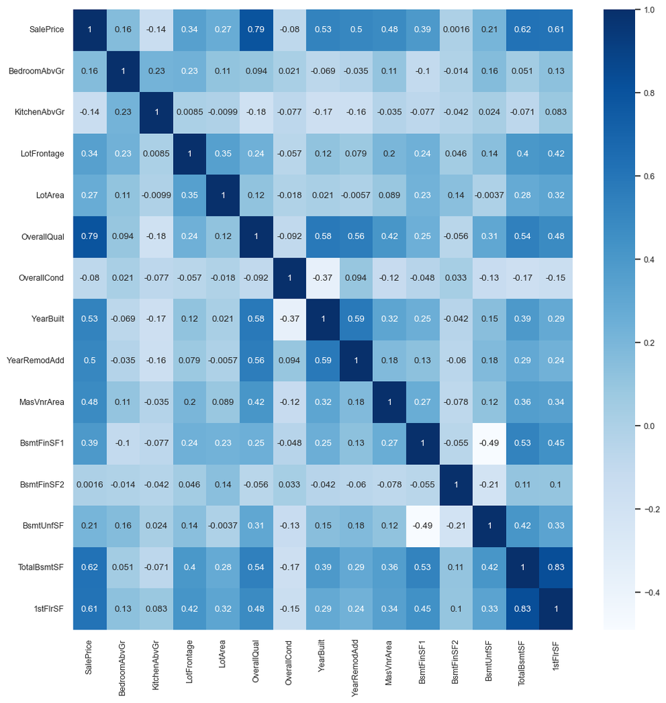

```python
cor = pd.concat((y_train, X_train_enc), axis=1).iloc[:, :15].corr()
plt.figure(figsize=(12, 12))
sns.set(font_scale=0.8)
sns.heatmap(cor, annot=True, cmap=plt.cm.Blues);
```

- We can immediately see that `SalePrice` is highly correlated with `OverallQual`.
- This is an early hint that `OverallQual` is a useful feature in predicting `SalePrice`.
- However, this approach is **extremely simplistic**.
  - It only looks at each feature in isolation.
  - It only looks at linear associations:
    - What if `SalePrice` is high when `BsmtFullBath` is 2 or 3, but low when it's 0, 1, or 4? They might seem uncorrelated.

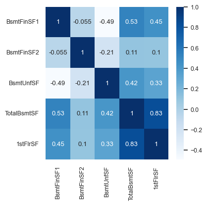

```python
cor = pd.concat((y_train, X_train_enc), axis=1).iloc[:, 10:15].corr()
plt.figure(figsize=(4, 4))
sns.set(font_scale=0.8)
sns.heatmap(cor, annot=True, cmap=plt.cm.Blues);
```

- Looking at this diagram also tells us the relationship between features.
  - For example, `1stFlrSF` and `TotalBsmtSF` are highly correlated.
  - Do we need both of them?
  - If our model says `1stFlrSF` is very important and `TotalBsmtSF` is very unimportant, do we trust those values?
  - Maybe `TotalBsmtSF` only "becomes important" if `1stFlrSF` is removed.
  - Sometimes the opposite happens: a feature only becomes important if another feature is *added*.

## Feature importances in linear models

- With linear regression we can look at the *coefficients* for each feature.
- Overall idea: predicted price = intercept + $\sum_i$ coefficient i $\times$ feature i.

```python
lr = make_pipeline(preprocessor, Ridge())
lr.fit(X_train, y_train);
```

Let's look at the coefficients.

```python
lr_coefs = pd.DataFrame(data=lr.named_steps['ridge'].coef_,
                        index=new_columns,
                        columns=["Coefficient"])
lr_coefs.head(20)
```

|  | Coefficient |
| --- | --- |
| BedroomAbvGr | -3723.741570 |
| KitchenAbvGr | -4580.204576 |
| LotFrontage | -1578.664421 |
| LotArea | 5109.356718 |
| OverallQual | 12487.561839 |
| OverallCond | 4855.535334 |
| YearBuilt | 4226.684842 |
| YearRemodAdd | 324.664715 |
| MasVnrArea | 5251.325210 |
| BsmtFinSF1 | 3667.172851 |
| BsmtFinSF2 | 583.114880 |
| BsmtUnfSF | -1266.614671 |
| TotalBsmtSF | 2751.084018 |
| 1stFlrSF | 6736.788904 |
| 2ndFlrSF | 13409.901084 |
| LowQualFinSF | -448.424132 |
| GrLivArea | 15988.182407 |
| BsmtFullBath | 2299.227266 |
| BsmtHalfBath | 500.169112 |
| FullBath | 2831.811467 |

### Interpreting coefficients of different types of features.

### Ordinal features

- The ordinal features are easiest to interpret.

```python
print(ordinal_features_reg)
```

```
['ExterQual', 'ExterCond', 'BsmtQual', 'BsmtCond', 'HeatingQC', 'KitchenQual', 'FireplaceQu', 'GarageQual', 'GarageCond', 'PoolQC']
```

```python
lr_coefs.loc["ExterQual"]
```

```
Coefficient    4195.671512
Name: ExterQual, dtype: float64
```

- Increasing by one category of exterior quality (e.g. good -> excellent) increases the predicted price by $\sim\$4195$.
  - Wow, that's a lot!
  - Remember this is just what the model has learned. It doesn't tell us how the world works.

```python
one_example = X_test[:1]
```

```python
one_example[["ExterQual"]]
```

|  | ExterQual |
| --- | --- |
| 147 | Gd |

Let's perturb the example and change `ExterQual` to `Ex`.

```python
one_example_perturbed = one_example.copy()
one_example_perturbed["ExterQual"] = "Ex"  # Change Gd to Ex
```

```python
one_example_perturbed[["ExterQual"]]
```

|  | ExterQual |
| --- | --- |
| 147 | Ex |

How does the prediction change after changing `ExterQual` from `Gd` to `Ex`?

```python
print("Prediction on the original example: ", lr.predict(one_example))
print("Prediction on the perturbed example: ", lr.predict(one_example_perturbed))
print(
    "After changing ExterQual from Gd to Ex increased the prediction by: ",
    lr.predict(one_example_perturbed) - lr.predict(one_example),
)
```

```
Prediction on the original example:  [224795.63596802]
Prediction on the perturbed example:  [228991.30748049]
After changing ExterQual from Gd to Ex increased the prediction by:  [4195.67151247]
```

That's exactly the learned coefficient for `ExterQual`!

```python
lr_coefs.loc["ExterQual"]
```

```
Coefficient    4195.671512
Name: ExterQual, dtype: float64
```

So our interpretation is correct!

- Increasing by one category of exterior quality (e.g. good -> excellent) increases the predicted price by $\sim\$4195$.

### Categorical features

- What about the categorical features?
- We have created a number of columns for each category with OHE and each category gets it's own coefficient.

```python
print(categorical_features)
```

[output not shown]

```python
lr_coefs_landslope = lr_coefs[lr_coefs.index.str.startswith("LandSlope")]
lr_coefs_landslope
```

|  | Coefficient |
| --- | --- |
| LandSlope_Gtl | 457.197456 |
| LandSlope_Mod | 7420.208381 |
| LandSlope_Sev | -7877.405837 |

- We can talk about switching from one of these categories to another by picking a "reference" category:

```python
lr_coefs_landslope - lr_coefs_landslope.loc["LandSlope_Gtl"]
```

|  | Coefficient |
| --- | --- |
| LandSlope_Gtl | 0.000000 |
| LandSlope_Mod | 6963.010925 |
| LandSlope_Sev | -8334.603292 |

- If you change the category from `LandSlope_Gtl` to `LandSlope_Mod` the prediction price goes up by $\sim\$6963$
- If you change the category from `LandSlope_Gtl` to `LandSlope_Sev` the prediction price goes down by $\sim\$8334$

Note that this might not make sense in the real world but this is what our model decided to learn given this small amount of data.

```python
lr_coefs.sort_values(by="Coefficient")
```

|  | Coefficient |
| --- | --- |
| RoofMatl_ClyTile | -191129.774314 |
| Condition2_PosN | -105552.840565 |
| Heating_OthW | -27260.681308 |
| MSZoning_C (all) | -21990.746193 |
| Exterior1st_ImStucc | -19393.964621 |
| ... | ... |
| PoolQC | 34217.656047 |
| RoofMatl_CompShg | 36525.980874 |
| Neighborhood_NridgHt | 37532.643270 |
| Neighborhood_StoneBr | 39993.978324 |
| RoofMatl_WdShngl | 83646.711008 |

263 rows × 1 columns

- For example, the above coefficient says that "If the roof is made of clay or tile, the predicted price is \$191K less"?
- Do we believe these interpretations??
  - Do we believe this is how the predictions are being computed? Yes.
  - Do we believe that this is how the world works? No.

### Interpreting coefficients of numeric features

Let's look at coefficients of `PoolArea`, `LotFrontage`, `LotArea`.

```python
lr_coefs.loc[["PoolArea", "LotFrontage", "LotArea"]]
```

|  | Coefficient |
| --- | --- |
| PoolArea | 2822.370476 |
| LotFrontage | -1578.664421 |
| LotArea | 5109.356718 |

Intuition:

- Tricky because numeric features are **scaled**!
- **Increasing** `PoolArea` by 1 scaled unit **increases** the predicted price by $\sim\$2822$.
- **Increasing** `LotArea` by 1 scaled unit **increases** the predicted price by $\sim\$5109$.
- **Increasing** `LotFrontage` by 1 scaled unit **decreases** the predicted price by $\sim\$1578$.

Does that sound reasonable?

- For `PoolArea` and `LotArea`, yes.
- For `LotFrontage`, that's surprising. Something positive would have made more sense?

BTW, let's make sure the predictions behave as expected:

```python
one_example = X_test[:1]
```

```python
one_example
```

|  | Id | MSSubClass | MSZoning | LotFrontage | LotArea | Street | Alley | LotShape | LandContour | Utilities | ... | ScreenPorch | PoolArea | PoolQC | Fence | MiscFeature | MiscVal | MoSold | YrSold | SaleType | SaleCondition |
| --- | --- | --- | --- | --- | --- | --- | --- | --- | --- | --- | --- | --- | --- | --- | --- | --- | --- | --- | --- | --- | --- |
| 147 | 148 | 60 | RL | NaN | 9505 | Pave | NaN | IR1 | Lvl | AllPub | ... | 0 | 0 | NaN | NaN | NaN | 0 | 5 | 2010 | WD | Normal |

1 rows × 80 columns

Let's perturb the example and add 1 to the LotArea.

```python
one_example_perturbed = one_example.copy()
one_example_perturbed["LotArea"] += 1  # add 1 to the LotArea
```

```python
one_example_perturbed
```

|  | Id | MSSubClass | MSZoning | LotFrontage | LotArea | Street | Alley | LotShape | LandContour | Utilities | ... | ScreenPorch | PoolArea | PoolQC | Fence | MiscFeature | MiscVal | MoSold | YrSold | SaleType | SaleCondition |
| --- | --- | --- | --- | --- | --- | --- | --- | --- | --- | --- | --- | --- | --- | --- | --- | --- | --- | --- | --- | --- | --- |
| 147 | 148 | 60 | RL | NaN | 9506 | Pave | NaN | IR1 | Lvl | AllPub | ... | 0 | 0 | NaN | NaN | NaN | 0 | 5 | 2010 | WD | Normal |

1 rows × 80 columns

Prediction on the original example.

```python
lr.predict(one_example)
```

```
array([224795.63596802])
```

Prediction on the perturbed example.

```python
lr.predict(one_example_perturbed)
```

```
array([224796.2040233])
```

- What's the difference between prediction?
- Does the difference make sense given the coefficient of the feature?

```python
lr.predict(one_example_perturbed) - lr.predict(one_example)
```

```
array([0.56805528])
```

```python
lr_coefs.loc[["LotArea"]]
```

|  | Coefficient |
| --- | --- |
| LotArea | 5109.356718 |

- Why did the prediction only go up by \$0.57 instead of \\$5109?
- This is an issue of units. `LotArea` is in sqft, but the coefficient is not $\$5109/\text{sqft}$ **because we scaled the features**.

#### Example showing how can we interpret coefficients of scaled features.

- What's one scaled unit for `LotArea`?
- The scaler subtracted the mean and divided by the standard deviation.
- The division actually changed the scale!
- For the unit conversion, we don't care about the subtraction, but only the scaling.

```python
scaler = preprocessor.named_transformers_["pipeline-1"]["standardscaler"]
```

```python
lr_scales = pd.DataFrame(
    data=np.sqrt(scaler.var_), index=numeric_features, columns=["Scale"]
)
lr_scales.head()
```

|  | Scale |
| --- | --- |
| BedroomAbvGr | 0.821040 |
| KitchenAbvGr | 0.218760 |
| LotFrontage | 20.959139 |
| LotArea | 8994.471032 |
| OverallQual | 1.392082 |

- It seems like `LotArea` was divided by 8994.471032 sqft.

```python
lr_coefs.loc[["LotArea"]]
```

|  | Coefficient |
| --- | --- |
| LotArea | 5109.356718 |

- The coefficient tells us that if we increase the **scaled** `LotArea` by one scaled unit the price would go up by $\approx\$5109$.
- One scaled unit represents $\sim 8994$ sq feet.
- So if I increase original `LotArea` by one square foot then the predicted price would go up by this amount:

```python
5109.356718094072 / 8994.471032
```

```
0.5680552752814816
```

- This makes much more sense. Now we get the number we got before.
- That said don't read too much into these coefficients without statistical training.

```python
one_example = X_test[:1]
```

```python
one_example
```

|  | Id | MSSubClass | MSZoning | LotFrontage | LotArea | Street | Alley | LotShape | LandContour | Utilities | ... | ScreenPorch | PoolArea | PoolQC | Fence | MiscFeature | MiscVal | MoSold | YrSold | SaleType | SaleCondition |
| --- | --- | --- | --- | --- | --- | --- | --- | --- | --- | --- | --- | --- | --- | --- | --- | --- | --- | --- | --- | --- | --- |
| 147 | 148 | 60 | RL | NaN | 9505 | Pave | NaN | IR1 | Lvl | AllPub | ... | 0 | 0 | NaN | NaN | NaN | 0 | 5 | 2010 | WD | Normal |

1 rows × 80 columns

Let's perturb the example and add 1 to the `LotArea`.

```python
one_example_perturbed = one_example.copy()
one_example_perturbed["LotArea"] += 1  # add 1 to the LotArea
```

```python
one_example_perturbed
```

|  | Id | MSSubClass | MSZoning | LotFrontage | LotArea | Street | Alley | LotShape | LandContour | Utilities | ... | ScreenPorch | PoolArea | PoolQC | Fence | MiscFeature | MiscVal | MoSold | YrSold | SaleType | SaleCondition |
| --- | --- | --- | --- | --- | --- | --- | --- | --- | --- | --- | --- | --- | --- | --- | --- | --- | --- | --- | --- | --- | --- |
| 147 | 148 | 60 | RL | NaN | 9506 | Pave | NaN | IR1 | Lvl | AllPub | ... | 0 | 0 | NaN | NaN | NaN | 0 | 5 | 2010 | WD | Normal |

1 rows × 80 columns

```python
lr.predict(one_example)
```

```
array([224795.63596802])
```

Prediction on the perturbed example.

```python
lr.predict(one_example_perturbed)
```

```
array([224796.2040233])
```

- What's the difference between prediction?
- Does the difference make sense given the coefficient of the feature?

```python
lr.predict(one_example_perturbed) - lr.predict(one_example)
```

```
array([0.56805528])
```

### Interim summary

- Correlation among features might make coefficients completely uninterpretable.
- Fairly straightforward to interpret coefficients of ordinal features.
- In categorical features, it's often helpful to consider one category as a reference point and think about relative importance.
- For numeric features, relative importance is meaningful after scaling.
- You have to be careful about the scale of the feature when interpreting the coefficients.
- Remember that explaining the model $\neq$ explaining the data.
- The coefficients tell us only about the model and they might not accurately reflect the data.

## Transparency and explainability of ML models

[figure not shown]

[Source](https://github.com/slundberg/shap/blob/master/docs/presentations/February%202018%20Talk.pptx)

### Discussion

- If you have a machine learning model which gives you 98% cross-validation accuracy and 97% test accuracy on a reasonable sized train and test data on the task of your interest.
- Is it OK to just trust the model and ignore why it made a certain prediction?
- Discuss scenarios where this might be problematic.

### Why do we care about transparency and interpretability?

- Transparency of ML model predictions is crucial in many applications such as banking, healthcare, and criminal justice.
- It can be leveraged by domain experts to diagnose systematic errors and underlying biases of complex ML systems.

[figure not shown]

[Source](https://github.com/slundberg/shap/blob/master/docs/presentations/February%202018%20Talk.pptx)

### What is model interpretability?

- In this lecture, our definition of model interpretability will be looking at **feature importances**.
- There is more to interpretability than feature importances, but it's a good start!
- Resource:
  - [Interpretable Machine Learning](https://christophm.github.io/interpretable-ml-book/interpretability-importance.html)
  - [Yann LeCun, Kilian Weinberger, Patrice Simard, and Rich Caruana: Panel debate on interpretability](https://vimeo.com/252187813)

### Data

- Let's work with [the adult census data set](https://www.kaggle.com/uciml/adult-census-income) from last lecture.

```python
adult_df_large = pd.read_csv("data/adult.csv")
train_df, test_df = train_test_split(adult_df_large, test_size=0.2, random_state=42)
train_df = train_df.replace("?", np.NaN)
test_df = test_df.replace("?", np.NaN)
train_df.head()
```

|  | age | workclass | fnlwgt | education | education.num | marital.status | occupation | relationship | race | sex | capital.gain | capital.loss | hours.per.week | native.country | income |
| --- | --- | --- | --- | --- | --- | --- | --- | --- | --- | --- | --- | --- | --- | --- | --- |
| 5514 | 26 | Private | 256263 | HS-grad | 9 | Never-married | Craft-repair | Not-in-family | White | Male | 0 | 0 | 25 | United-States | <=50K |
| 19777 | 24 | Private | 170277 | HS-grad | 9 | Never-married | Other-service | Not-in-family | White | Female | 0 | 0 | 35 | United-States | <=50K |
| 10781 | 36 | Private | 75826 | Bachelors | 13 | Divorced | Adm-clerical | Unmarried | White | Female | 0 | 0 | 40 | United-States | <=50K |
| 32240 | 22 | State-gov | 24395 | Some-college | 10 | Married-civ-spouse | Adm-clerical | Wife | White | Female | 0 | 0 | 20 | United-States | <=50K |
| 9876 | 31 | Local-gov | 356689 | Bachelors | 13 | Married-civ-spouse | Prof-specialty | Husband | White | Male | 0 | 0 | 40 | United-States | <=50K |

```python
numeric_features = ["capital.gain", "age", "capital.loss", "hours.per.week"]
categorical_features = [
    "marital.status",
    "native.country",
    "relationship",
    "occupation",
    "workclass",
]
ordinal_features = ["education"]
binary_features = ["sex"]
drop_features = ["fnlwgt", "race", "education.num"]
target_column = "income"
```

```python
education_levels = [
    "Preschool",
    "1st-4th",
    "5th-6th",
    "7th-8th",
    "9th",
    "10th",
    "11th",
    "12th",
    "HS-grad",
    "Prof-school",
    "Assoc-voc",
    "Assoc-acdm",
    "Some-college",
    "Bachelors",
    "Masters",
    "Doctorate",
]
```

```python
assert set(education_levels) == set(train_df["education"].unique())
```

```python
numeric_transformer = StandardScaler()
ordinal_transformer = OrdinalEncoder(categories=[education_levels], dtype=int)
binary_transformer = OneHotEncoder(drop="if_binary", dtype=int)
categorical_transformer = make_pipeline(
    SimpleImputer(strategy="constant", fill_value="missing"),
    OneHotEncoder(handle_unknown="ignore", sparse=False),
)

preprocessor = make_column_transformer(
    (numeric_transformer, numeric_features),
    (ordinal_transformer, ordinal_features),
    (binary_transformer, binary_features),
    (categorical_transformer, categorical_features),
    ("drop", drop_features),
)
```

```python
X_train = train_df.drop(columns=[target_column])
y_train = train_df[target_column]

X_test = test_df.drop(columns=[target_column])
y_test = test_df[target_column]
```

```python
preprocessor.fit(X_train, y_train)
```

```
ColumnTransformer(transformers=[('standardscaler', StandardScaler(),
                                 ['capital.gain', 'age', 'capital.loss',
                                  'hours.per.week']),
                                ('ordinalencoder',
                                 OrdinalEncoder(categories=[['Preschool',
                                                             '1st-4th',
                                                             '5th-6th',
                                                             '7th-8th', '9th',
                                                             '10th', '11th',
                                                             '12th', 'HS-grad',
                                                             'Prof-school',
                                                             'Assoc-voc',
                                                             'Assoc-acdm',
                                                             'Some-college',
                                                             'Bachelors',
                                                             'Masters',
                                                             'Doctorate']],
                                                dtype=<class...
                                 OneHotEncoder(drop='if_binary',
                                               dtype=<class 'int'>),
                                 ['sex']),
                                ('pipeline',
                                 Pipeline(steps=[('simpleimputer',
                                                  SimpleImputer(fill_value='missing',
                                                                strategy='constant')),
                                                 ('onehotencoder',
                                                  OneHotEncoder(handle_unknown='ignore',
                                                                sparse=False))]),
                                 ['marital.status', 'native.country',
                                  'relationship', 'occupation', 'workclass']),
                                ('drop', 'drop',
                                 ['fnlwgt', 'race', 'education.num'])])
```

```python
ohe_feats = (
    preprocessor.named_transformers_["pipeline"]
    .named_steps["onehotencoder"]
    .get_feature_names_out(categorical_features)
).tolist()
```

```python
feature_names = numeric_features + ordinal_features + binary_features + ohe_feats
```

### Do we have class imbalance?

- There is class imbalance. But without any context, both classes seem equally important.
- Let's use accuracy as our metric.

```python
train_df["income"].value_counts(normalize=True)
```

```
<=50K    0.757985
>50K     0.242015
Name: income, dtype: float64
```

```python
scoring_metric = "accuracy"
```

Let's store all the results in a dictionary called `results`.

```python
results = {}
```

```python
scoring_metric = "accuracy"
```

```python
from lightgbm.sklearn import LGBMClassifier

pipe_lr = make_pipeline(
    preprocessor, LogisticRegression(max_iter=2000, random_state=123)
)
pipe_rf = make_pipeline(preprocessor, RandomForestClassifier(random_state=123))

pipe_lgbm = make_pipeline(preprocessor, LGBMClassifier(random_state=123))
classifiers = {
    "logistic regression": pipe_lr,
    "random forest": pipe_rf,
    "LightGBM": pipe_lgbm,
}
```

```python
dummy = DummyClassifier(strategy="stratified")
results["Dummy"] = mean_std_cross_val_scores(
    dummy, X_train, y_train, return_train_score=True, scoring=scoring_metric
)
```

```python
for (name, model) in classifiers.items():
    results[name] = mean_std_cross_val_scores(
        model, X_train, y_train, return_train_score=True, scoring=scoring_metric
    )
```

```python
pd.DataFrame(results).T
```

|  | fit_time | score_time | test_score | train_score |
| --- | --- | --- | --- | --- |
| Dummy | 0.013 (+/- 0.001) | 0.009 (+/- 0.001) | 0.630 (+/- 0.008) | 0.632 (+/- 0.003) |
| logistic regression | 1.856 (+/- 0.211) | 0.026 (+/- 0.001) | 0.849 (+/- 0.005) | 0.850 (+/- 0.001) |
| random forest | 2.102 (+/- 0.047) | 0.150 (+/- 0.007) | 0.848 (+/- 0.006) | 0.979 (+/- 0.000) |
| LightGBM | 0.801 (+/- 0.084) | 0.050 (+/- 0.004) | 0.872 (+/- 0.004) | 0.888 (+/- 0.000) |

- Logistic regression is giving reasonable scores but not the best ones.
- LightGBM is giving us the best CV scores.
- Often simple models (e.g., linear models) are interpretable but not very accurate.
- Complex models (e.g., LightGBM) are more accurate but less interpretable.

[figure not shown]

[Source](https://github.com/slundberg/shap/blob/master/docs/presentations/February%202018%20Talk.pptx)

### Feature importances in linear models

- Simpler models are often more interpretable but less accurate.

Let's create and fit a pipeline with preprocessor and logistic regression.

```python
pipe_lr = make_pipeline(preprocessor, LogisticRegression(max_iter=2000, random_state=2))
pipe_lr.fit(X_train, y_train);
```

```python
ohe_feature_names = (
    pipe_rf.named_steps["columntransformer"]
    .named_transformers_["pipeline"]
    .named_steps["onehotencoder"]
    .get_feature_names(categorical_features)
    .tolist()
)
feature_names = (
    numeric_features + ordinal_features + binary_features + ohe_feature_names
)
feature_names[:10]
```

```
['capital.gain',
 'age',
 'capital.loss',
 'hours.per.week',
 'education',
 'sex',
 'marital.status_Divorced',
 'marital.status_Married-AF-spouse',
 'marital.status_Married-civ-spouse',
 'marital.status_Married-spouse-absent']
```

```python
data = {
    "coefficient": pipe_lr.named_steps["logisticregression"].coef_[0].tolist(),
    "magnitude": np.absolute(
        pipe_lr.named_steps["logisticregression"].coef_[0].tolist()
    ),
}
coef_df = pd.DataFrame(data, index=feature_names).sort_values(
    "magnitude", ascending=False
)
```

```python
coef_df[:10]
```

|  | coefficient | magnitude |
| --- | --- | --- |
| capital.gain | 2.356217 | 2.356217 |
| marital.status_Married-AF-spouse | 1.745230 | 1.745230 |
| occupation_Priv-house-serv | -1.420325 | 1.420325 |
| marital.status_Married-civ-spouse | 1.326196 | 1.326196 |
| relationship_Wife | 1.265513 | 1.265513 |
| native.country_Columbia | -1.089615 | 1.089615 |
| occupation_Prof-specialty | 1.064969 | 1.064969 |
| occupation_Exec-managerial | 1.042863 | 1.042863 |
| native.country_Dominican-Republic | -1.016502 | 1.016502 |
| relationship_Own-child | -1.011340 | 1.011340 |

- Increasing `capital.gain` is likely to push the prediction towards ">50k" income class
- Whereas occupation of private house service is likely to push the prediction towards "<=50K" income.

Can we get feature importances for non-linear models?

## Model interpretability beyond linear models

We will be looking at three ways for model interpretability.

- `sklearn` `feature_importances_`
- [eli5](https://eli5.readthedocs.io/en/latest/tutorials/black-box-text-classifiers.html#lime-tutorial) (stands for "explain like I'm 5")
- [SHAP](https://github.com/slundberg/shap)

### Feature importances activity

We have been talking about feature importances given by linear models. How about other models we have seen so far? What might be reasonable ways to calculate feature importances of other models we have seen so far?

- Decision trees
- Other tree-based models such as random forests or LightGBM
- Linear SVMs
- KNNs, RBF SVMs

### `sklearn` `feature_importances_`

#### Decision tre feature importances

```python
pipe_dt = make_pipeline(preprocessor, DecisionTreeClassifier(max_depth=3))
pipe_dt.fit(X_train, y_train);
```

```python
data = {
    "Importance": pipe_dt.named_steps["decisiontreeclassifier"].feature_importances_,
}
pd.DataFrame(data=data, index=feature_names,).sort_values(
    by="Importance", ascending=False
)[:10]
```

|  | Importance |
| --- | --- |
| marital.status_Married-civ-spouse | 0.543351 |
| capital.gain | 0.294855 |
| education | 0.160727 |
| age | 0.001068 |
| native.country_missing | 0.000000 |
| occupation_Armed-Forces | 0.000000 |
| occupation_Adm-clerical | 0.000000 |
| relationship_Wife | 0.000000 |
| relationship_Unmarried | 0.000000 |
| relationship_Own-child | 0.000000 |

```python
display_tree(feature_names, pipe_dt.named_steps["decisiontreeclassifier"], counts=True)
```

[figure not shown]

Let's create and fit a pipeline with preprocessor and random forest.

#### Random forest feature importances

```python
pipe_rf = make_pipeline(preprocessor, RandomForestClassifier(random_state=2))
pipe_rf.fit(X_train, y_train);
```

Which features are driving the predictions the most?

```python
data = {
    "Importance": pipe_rf.named_steps["randomforestclassifier"].feature_importances_,
}
rf_imp_df = pd.DataFrame(
    data=data,
    index=feature_names,
).sort_values(by="Importance", ascending=False)
```

```python
rf_imp_df[:8]
```

|  | Importance |
| --- | --- |
| age | 0.231760 |
| education | 0.117826 |
| hours.per.week | 0.115728 |
| capital.gain | 0.108464 |
| marital.status_Married-civ-spouse | 0.075335 |
| relationship_Husband | 0.050766 |
| capital.loss | 0.037180 |
| marital.status_Never-married | 0.028449 |

```python
np.sum(pipe_rf.named_steps["randomforestclassifier"].feature_importances_)
```

```
1.0
```

### Key point

- Unlike the linear model coefficients, `feature_importances_` **do not have a sign**!
  - They tell us about importance, but not an "up or down".
  - Indeed, increasing a feature may cause the prediction to first go up, and then go down.
  - This cannot happen in linear models, because they are linear.

Do these importances match with importances identified by logistic regression?

```python
pipe_lr.fit(X_train, y_train)
```

```
Pipeline(steps=[('columntransformer',
                 ColumnTransformer(transformers=[('standardscaler',
                                                  StandardScaler(),
                                                  ['capital.gain', 'age',
                                                   'capital.loss',
                                                   'hours.per.week']),
                                                 ('ordinalencoder',
                                                  OrdinalEncoder(categories=[['Preschool',
                                                                              '1st-4th',
                                                                              '5th-6th',
                                                                              '7th-8th',
                                                                              '9th',
                                                                              '10th',
                                                                              '11th',
                                                                              '12th',
                                                                              'HS-grad',
                                                                              'Prof-school',
                                                                              'Assoc-voc',
                                                                              'Assoc-acdm',
                                                                              'Some-college',
                                                                              'Bachelors'...
                                                  Pipeline(steps=[('simpleimputer',
                                                                   SimpleImputer(fill_value='missing',
                                                                                 strategy='constant')),
                                                                  ('onehotencoder',
                                                                   OneHotEncoder(handle_unknown='ignore',
                                                                                 sparse=False))]),
                                                  ['marital.status',
                                                   'native.country',
                                                   'relationship', 'occupation',
                                                   'workclass']),
                                                 ('drop', 'drop',
                                                  ['fnlwgt', 'race',
                                                   'education.num'])])),
                ('logisticregression',
                 LogisticRegression(max_iter=2000, random_state=2))])
```

```python
data = {
    "random forest importance": pipe_rf.named_steps[
        "randomforestclassifier"
    ].feature_importances_,
    "logistic regression importances": pipe_lr.named_steps["logisticregression"]
    .coef_[0]
    .tolist(),
}
imps = pd.DataFrame(
    data=data,
    index=feature_names,
)
```

```python
imps.sort_values(by="random forest importance", ascending=False)[:10]
```

|  | random forest importance | logistic regression importances |
| --- | --- | --- |
| age | 0.231760 | 0.353605 |
| education | 0.117826 | 0.183876 |
| hours.per.week | 0.115728 | 0.367690 |
| capital.gain | 0.108464 | 2.356217 |
| marital.status_Married-civ-spouse | 0.075335 | 1.326196 |
| relationship_Husband | 0.050766 | -0.029444 |
| capital.loss | 0.037180 | 0.280465 |
| marital.status_Never-married | 0.028449 | -0.952345 |
| occupation_Exec-managerial | 0.022496 | 1.042863 |
| occupation_Prof-specialty | 0.020883 | 1.064969 |

- Both models agree on `age`, `education`, `capital.gain`
- The actual numbers for random forests and logistic regression are not really comparable.

### How can we get feature importances for non `sklearn` models?

- One way to do it is by using a tool called [`eli5`](https://eli5.readthedocs.io/en/latest/overview.html).

You need to install it:

```
conda install -c conda-forge eli5
```

Let's look at feature importances for `LGBMClassifier`.

```python
import eli5

pipe_lgbm = make_pipeline(preprocessor, LGBMClassifier(random_state=123))
pipe_lgbm.fit(X_train, y_train)
eli5.explain_weights(
    pipe_lgbm.named_steps["lgbmclassifier"], feature_names=feature_names
)
```

| Weight | Feature |
| --- | --- |
| 0.3613 | marital.status_Married-civ-spouse |
| 0.1941 | capital.gain |
| 0.1411 | education |
| 0.0890 | age |
| 0.0659 | capital.loss |
| 0.0440 | hours.per.week |
| 0.0131 | occupation_Exec-managerial |
| 0.0115 | occupation_Prof-specialty |
| 0.0072 | occupation_Other-service |
| 0.0063 | sex |
| 0.0056 | relationship_Wife |
| 0.0055 | workclass_Self-emp-not-inc |
| 0.0055 | occupation_Farming-fishing |
| 0.0054 | relationship_Own-child |
| 0.0030 | occupation_Tech-support |
| 0.0030 | occupation_Sales |
| 0.0026 | workclass_Federal-gov |
| 0.0026 | workclass_Private |
| 0.0023 | occupation_Handlers-cleaners |
| 0.0022 | workclass_Self-emp-inc |
| *… 65 more …* |  |

You can also look at feature importances for `RandomForestClassifier`.

```python
pipe_rf = make_pipeline(preprocessor, RandomForestClassifier(random_state=123))
pipe_rf.fit(X_train, y_train)

eli5.explain_weights(
    pipe_rf.named_steps["randomforestclassifier"], feature_names=feature_names
)
```

| Weight | Feature |
| --- | --- |
| 0.2353 ± 0.0451 | age |
| 0.1191 ± 0.0332 | education |
| 0.1157 ± 0.0218 | hours.per.week |
| 0.1093 ± 0.0510 | capital.gain |
| 0.0728 ± 0.1350 | marital.status_Married-civ-spouse |
| 0.0471 ± 0.1144 | relationship_Husband |
| 0.0395 ± 0.0176 | capital.loss |
| 0.0251 ± 0.0711 | marital.status_Never-married |
| 0.0214 ± 0.0202 | occupation_Prof-specialty |
| 0.0212 ± 0.0209 | occupation_Exec-managerial |
| 0.0132 ± 0.0231 | sex |
| 0.0129 ± 0.0303 | relationship_Not-in-family |
| 0.0098 ± 0.0329 | relationship_Own-child |
| 0.0096 ± 0.0218 | relationship_Wife |
| 0.0096 ± 0.0044 | workclass_Private |
| 0.0088 ± 0.0048 | workclass_Self-emp-not-inc |
| 0.0077 ± 0.0069 | workclass_Self-emp-inc |
| 0.0075 ± 0.0071 | occupation_Other-service |
| 0.0071 ± 0.0026 | native.country_United-States |
| 0.0070 ± 0.0038 | occupation_Sales |
| *… 65 more …* |  |

Let's compare them with weights what we got with `sklearn` `feature_importances_`

```python
data = {
    "Importance": pipe_rf.named_steps["randomforestclassifier"].feature_importances_,
}
pd.DataFrame(data=data, index=feature_names,).sort_values(
    by="Importance", ascending=False
)[:10]
```

|  | Importance |
| --- | --- |
| age | 0.235295 |
| education | 0.119108 |
| hours.per.week | 0.115700 |
| capital.gain | 0.109320 |
| marital.status_Married-civ-spouse | 0.072808 |
| relationship_Husband | 0.047109 |
| capital.loss | 0.039513 |
| marital.status_Never-married | 0.025080 |
| occupation_Prof-specialty | 0.021440 |
| occupation_Exec-managerial | 0.021167 |

- These values tell us globally about which features are important.
- But what if you want to explain a *specific* prediction.
- Some fancier tools can help us do this.

### SHAP (SHapley Additive exPlanations)

- Based on the idea of shapely values. A shapely value is created for each example and each feature.
- Can explain the prediction of an example by computing the contribution of each feature to the prediction.
- Great visualizations
- Support for different kinds of models; fast variants for tree-based models
- Original paper: [Lundberg and Lee, 2017](https://arxiv.org/pdf/1705.07874.pdf)

#### Our focus

- How to use it on our dataset?
- How to generate and interpret plots created by SHAP?
- We are not going to discuss how SHAP works.
- Let's try it out on tree-based models.
- Install `shap` in the course conda environment.

```
conda install -c conda-forge shap
```

Let's create train and test dataframes with our transformed features.

```python
X_train_enc = pd.DataFrame(
    data=preprocessor.transform(X_train),
    columns=feature_names,
    index=X_train.index,
)
X_train_enc.head()
```

|  | capital.gain | age | capital.loss | hours.per.week | education | sex | marital.status_Divorced | marital.status_Married-AF-spouse | marital.status_Married-civ-spouse | marital.status_Married-spouse-absent | ... | occupation_missing | workclass_Federal-gov | workclass_Local-gov | workclass_Never-worked | workclass_Private | workclass_Self-emp-inc | workclass_Self-emp-not-inc | workclass_State-gov | workclass_Without-pay | workclass_missing |
| --- | --- | --- | --- | --- | --- | --- | --- | --- | --- | --- | --- | --- | --- | --- | --- | --- | --- | --- | --- | --- | --- |
| 5514 | -0.147166 | -0.921955 | -0.21768 | -1.258387 | 8.0 | 1.0 | 0.0 | 0.0 | 0.0 | 0.0 | ... | 0.0 | 0.0 | 0.0 | 0.0 | 1.0 | 0.0 | 0.0 | 0.0 | 0.0 | 0.0 |
| 19777 | -0.147166 | -1.069150 | -0.21768 | -0.447517 | 8.0 | 0.0 | 0.0 | 0.0 | 0.0 | 0.0 | ... | 0.0 | 0.0 | 0.0 | 0.0 | 1.0 | 0.0 | 0.0 | 0.0 | 0.0 | 0.0 |
| 10781 | -0.147166 | -0.185975 | -0.21768 | -0.042081 | 13.0 | 0.0 | 1.0 | 0.0 | 0.0 | 0.0 | ... | 0.0 | 0.0 | 0.0 | 0.0 | 1.0 | 0.0 | 0.0 | 0.0 | 0.0 | 0.0 |
| 32240 | -0.147166 | -1.216346 | -0.21768 | -1.663822 | 12.0 | 0.0 | 0.0 | 0.0 | 1.0 | 0.0 | ... | 0.0 | 0.0 | 0.0 | 0.0 | 0.0 | 0.0 | 0.0 | 1.0 | 0.0 | 0.0 |
| 9876 | -0.147166 | -0.553965 | -0.21768 | -0.042081 | 13.0 | 1.0 | 0.0 | 0.0 | 1.0 | 0.0 | ... | 0.0 | 0.0 | 1.0 | 0.0 | 0.0 | 0.0 | 0.0 | 0.0 | 0.0 | 0.0 |

5 rows × 85 columns

```python
X_test_enc = pd.DataFrame(
    data=preprocessor.transform(X_test),
    columns=feature_names,
    index=X_test.index,
)
X_test_enc.shape
```

```
(6513, 85)
```

Let's get SHAP values for train and test data.

To run the code below, you need to install SHAP as follows:

`conda install -c conda-forge shap`

```python
import shap

lgbm_explainer = shap.TreeExplainer(pipe_lgbm.named_steps["lgbmclassifier"])
train_lgbm_shap_values = lgbm_explainer.shap_values(X_train_enc)
```

```
LightGBM binary classifier with TreeExplainer shap values output has changed to a list of ndarray
```

```python
train_lgbm_shap_values
```

[output not shown]

- For each example, each feature, and each class we have a SHAP value.
- SHAP values tell us how to fairly distribute the prediction among features.
- For classification it's a bit confusing. It gives SHAP matrix for both classes.
- Let's stick to shap values for class 1, i.e., income > 50K.

```python
train_lgbm_shap_values[1].shape
```

```
(26048, 85)
```

```python
test_lgbm_shap_values = lgbm_explainer.shap_values(X_test_enc)
test_lgbm_shap_values[1].shape
```

```
(6513, 85)
```

## SHAP plots

### Force plots

- Most useful!
- Let's try to explain predictions on a couple of examples from the test data.
- I'm sampling some examples where target is <=50K and some examples where target is >50K.

```python
y_test_reset = y_test.reset_index(drop=True)
y_test_reset
```

```
0       <=50K
1       <=50K
2       <=50K
3       <=50K
4       <=50K
        ...
6508    <=50K
6509    <=50K
6510     >50K
6511    <=50K
6512     >50K
Name: income, Length: 6513, dtype: object
```

```python
l50k_ind = y_test_reset[y_test_reset == "<=50K"].index.tolist()
g50k_ind = y_test_reset[y_test_reset == ">50K"].index.tolist()

ex_l50k_index = l50k_ind[10]
ex_g50k_index = g50k_ind[10]
```

### Example with prediction <=50K

```python
pipe_lgbm.named_steps["lgbmclassifier"].classes_
```

```
array(['<=50K', '>50K'], dtype=object)
```

```python
pipe_lgbm.named_steps["lgbmclassifier"].predict_proba(X_test_enc)[ex_l50k_index]
```

```
array([0.99240562, 0.00759438])
```

```python
pipe_lgbm.named_steps["lgbmclassifier"].predict(X_test_enc, raw_score=True)[
    ex_l50k_index
]  # raw score of the model
```

```
-4.872722908439952
```

```python
pipe_lgbm.named_steps["lgbmclassifier"].predict(X_test_enc, raw_score=True)
```

```
array([-1.76270194, -7.61912405, -0.45555535, ...,  1.13521135,
       -6.62873917, -0.84062193])
```

```python
pipe_lgbm.named_steps["lgbmclassifier"].predict(X_train_enc, raw_score=True).mean()
```

```
-2.336411423367732
```

```python
lgbm_explainer.expected_value[1]  # on average this is the raw score for class 1
```

```
-2.3364114233677307
```

```python
lgbm_explainer.expected_value[0]
```

```
2.3364114233677307
```

```python
X_test_enc = round(X_test_enc, 3)  # for better visualization
```

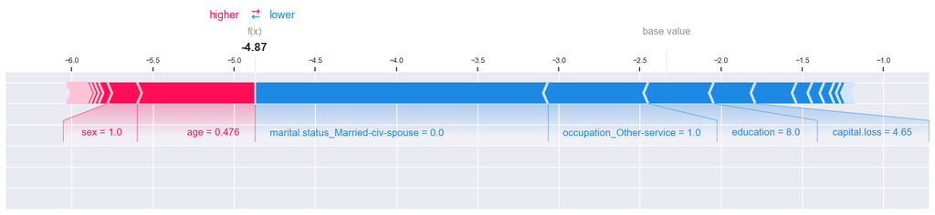

```python
shap.force_plot(
    lgbm_explainer.expected_value[1],
    test_lgbm_shap_values[1][ex_l50k_index, :],
    X_test_enc.iloc[ex_l50k_index, :],
    matplotlib=True,
)
```

- The raw model score is much smaller than the base value, which is reflected in the prediction of <= 50k class.
- sex = 1.0, scaled age = 0.48 are pushing the prediction towards higher score.
- education = 8.0, occupation_Other-service = 1.0 and marital.status_Married-civ-spouse = 0.0 are pushing the prediction towards lower score.

```python
pd.DataFrame(
    test_lgbm_shap_values[1][ex_l50k_index, :],
    index=feature_names,
    columns=["SHAP values"],
).sort_values('SHAP values', ascending=False)
```

|  | SHAP values |
| --- | --- |
| age | 0.723502 |
| sex | 0.183267 |
| marital.status_Never-married | 0.053894 |
| occupation_Machine-op-inspct | 0.026332 |
| relationship_Own-child | 0.024354 |
| ... | ... |
| capital.gain | -0.253426 |
| capital.loss | -0.256666 |
| education | -0.403715 |
| occupation_Other-service | -0.618201 |
| marital.status_Married-civ-spouse | -1.805103 |

85 rows × 1 columns

### Example with prediction >50K

```python
pipe_lgbm.named_steps["lgbmclassifier"].predict_proba(X_test_enc)[ex_g50k_index]
```

```
array([0.35997929, 0.64002071])
```

```python
pipe_lgbm.named_steps["lgbmclassifier"].predict(X_test_enc, raw_score=True)[
    ex_g50k_index
]  # raw model score
```

```
0.5754540510801829
```

```python
pd.DataFrame(
    test_lgbm_shap_values[1][ex_g50k_index, :],
    index=feature_names,
    columns=["SHAP values"],
)
```

|  | SHAP values |
| --- | --- |
| capital.gain | -0.295954 |
| age | 0.808705 |
| capital.loss | -0.088905 |
| hours.per.week | -0.688912 |
| education | 0.890873 |
| ... | ... |
| workclass_Self-emp-inc | -0.007650 |
| workclass_Self-emp-not-inc | -0.000750 |
| workclass_State-gov | 0.006082 |
| workclass_Without-pay | 0.000000 |
| workclass_missing | 0.000000 |

85 rows × 1 columns

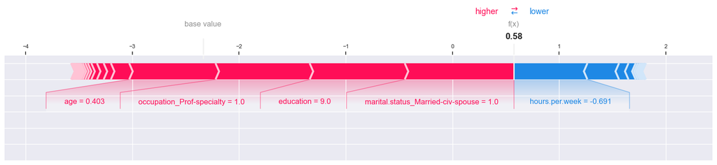

```python
shap.force_plot(
    lgbm_explainer.expected_value[1],
    test_lgbm_shap_values[1][ex_g50k_index, :],
    X_test_enc.iloc[ex_g50k_index, :],
    matplotlib=True,
)
```

Note: a nice thing about SHAP values is that the feature importances sum to the prediction:

```python
test_lgbm_shap_values[1][ex_g50k_index, :].sum() + lgbm_explainer.expected_value[1]
```

```
0.5754540510801851
```

### Global feature importance using SHAP

Let's look at the average SHAP values associated with each feature.

```python
values = np.abs(train_lgbm_shap_values[1]).mean(
    0
)  # mean of shapely values in each column
pd.DataFrame(data=values, index=feature_names, columns=["SHAP"]).sort_values(
    by="SHAP", ascending=False
)[:10]
```

|  | SHAP |
| --- | --- |
| marital.status_Married-civ-spouse | 1.074859 |
| age | 0.805466 |
| capital.gain | 0.565589 |
| education | 0.417642 |
| hours.per.week | 0.324636 |
| sex | 0.185686 |
| capital.loss | 0.148519 |
| marital.status_Never-married | 0.139913 |
| relationship_Own-child | 0.108002 |
| occupation_Prof-specialty | 0.106276 |

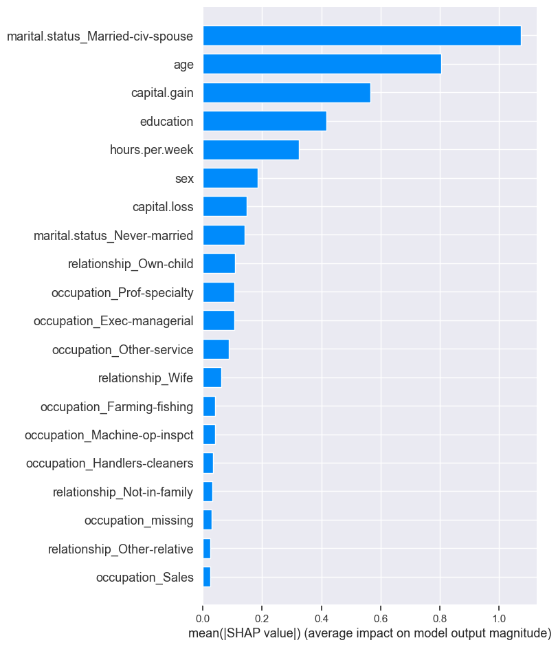

```python
shap.summary_plot(train_lgbm_shap_values[1], X_train_enc, plot_type="bar")
```

You can think of this as global feature importances.

```python
# load JS visualization code to notebook
shap.initjs()
```

### Dependence plot

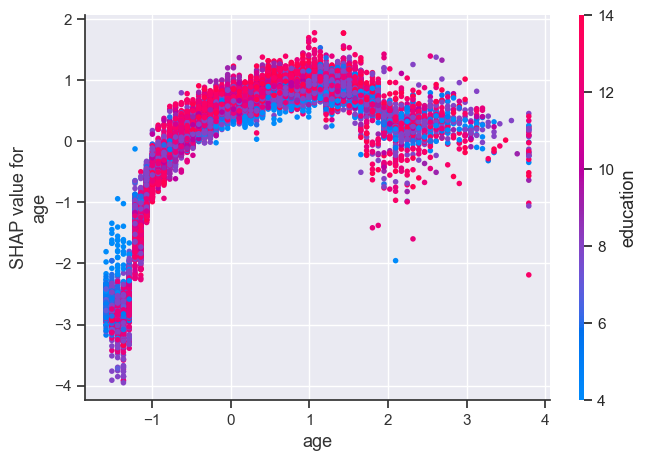

```python
shap.dependence_plot("age", train_lgbm_shap_values[1], X_train_enc)
```

The plot above shows effect of `age` feature on the prediction.

- Each dot is a single prediction for examples above.
- The x-axis represents values of the feature age (scaled).
- The y-axis is the SHAP value for that feature, which represents how much knowing that feature's value changes the output of the model for that example's prediction.
- Lower values of age have smaller SHAP values for class ">50K".
- Similarly, higher values of age also have a bit smaller SHAP values for class ">50K", which makes sense.
- There is some optimal value of age between scaled age of 1 which gives highest SHAP values for for class ">50K".
- Ignore the colour for now. The color corresponds to a second feature (education feature in this case) that may have an interaction effect with the feature we are plotting.

### Summary plot

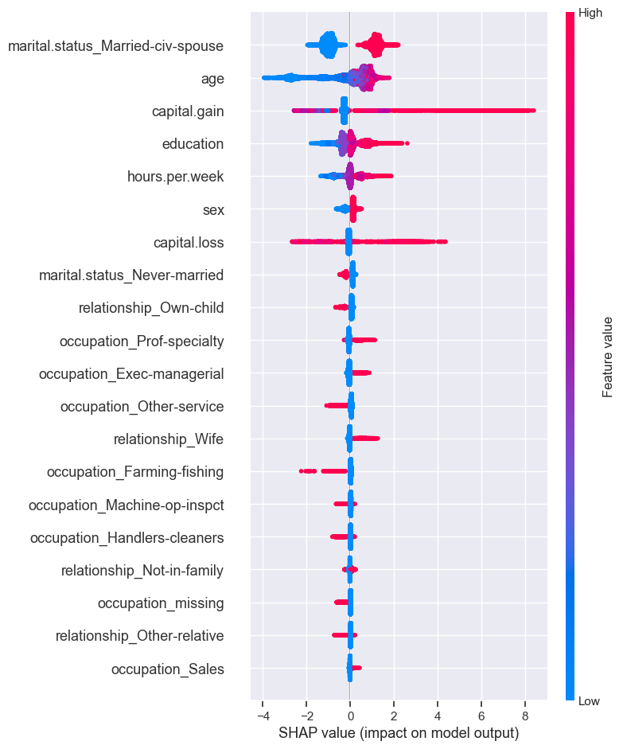

```python
shap.summary_plot(train_lgbm_shap_values[1], X_train_enc)
```

The plot shows the most important features for predicting the class. It also shows the direction of how it's going to drive the prediction.

- Presence of the marital status of Married-civ-spouse seems to have bigger SHAP values for class 1 and absence seems to have smaller SHAP values for class 1.
- Higher levels of education seem to have bigger SHAP values for class 1 whereas smaller levels of education have smaller SHAP values.

Provides explainer for different kinds of models

- [TreeExplainer](https://shap.readthedocs.io/en/latest/) (supports XGBoost, CatBoost, LightGBM)
- DeepExplainer (supports deep-learning models)
- KernelExplainer (supports kernel-based models)
- GradientExplainer (supports Keras and Tensorflow models)
- Can also be used to explain text classification and image classification
- Example: In the picture below, red pixels represent positive SHAP values that increase the probability of the class, while blue pixels represent negative SHAP values the reduce the probability of the class.

[figure not shown]

[Source](https://github.com/slundberg/shap)

### Other tools

- lime is another package.

If you're not already impressed, keep in mind:

- So far we've only used sklearn models.
- Most sklearn models have some built-in measure of feature importances.
- On many tasks we need to move beyond sklearn, e.g. LightGBM, deep learning.
- These tools work on other models as well, which makes them extremely useful.

### ❓❓ Questions for you

### True/False

1. You train a random forest on a binary classification problem with two classes [neg, pos]. A value of 0.580 for feat1 given by `feature_importances_` attribute of your model means that increasing the value of feat1 will drive us towards positive class.
2. eli5 can be used to get feature importances for non `sklearn` models.
3. With SHAP you can only explain predictions on the training examples.

#### Why do we want this information?

Possible reasons:

- Identify features that are not useful and maybe remove them.
- Get guidance on what new data to collect.
  - New features related to useful features -> better results.
  - Don't bother collecting useless features -> save resources.
- Help explain why the model is making certain predictions.
  - Debugging, if the model is behaving strangely.
  - Regulatory requirements.
  - Fairness / bias.
  - Keep in mind this can be used on **deployment** predictions!